# Preliminary Data Visualization

Indigo Edwards

12/3/2021

## Reviewing Caterpillars Count! survey data

I’m starting by calculating the number of survey dates at each site in each year. Do we want to assess site usability based on the number of survey dates, or the number of total surveys?

| SiteID | Name | Year | survey_dates | Region | Latitude | Longitude |
| --- | --- | --- | --- | --- | --- | --- |
| 2 | NA | 2018 | 17 | NA | NA | NA |
| 2 | NA | 2019 | 38 | NA | NA | NA |
| 2 | NA | 2020 | 6 | NA | NA | NA |
| 2 | NA | 2021 | 8 | NA | NA | NA |
| 40 | Red Top Mountain State Park | 2018 | 4 | GA | 34.15 | -84.7 |
| 40 | Red Top Mountain State Park | 2019 | 1 | GA | 34.15 | -84.7 |

Sites 2 and 258 don’t exist in our sites data file. What are they?

Let’s look at how many sites had 10 or more surveys each year. I think it would be smart to conduct a power analysis before starting serious analysis, but we’ll have to think about whether that would be based on the number of survey dates or the number of total surveys. It probably depends on whether we’d be considering samples as a single survey or a single survey date - survey date seems like it makes more sense.

| Year | Sites w/ 10+ survey dates |
| --- | --- |
| 2006 | 2 |
| 2008 | 3 |
| 2010 | 2 |
| 2011 | 2 |
| 2012 | 2 |
| 2013 | 2 |
| 2014 | 2 |
| 2015 | 4 |
| 2016 | 4 |
| 2017 | 4 |
| 2018 | 23 |
| 2019 | 34 |
| 2020 | 22 |
| 2021 | 26 |

Unsurprisingly, it looks like only 2018 to 2021 have enough sites with a decent number of survey dates to be usable. It’s a pleasant surprise that 2020 might be usable, given the COVID issues with sampling. Let’s look at which sites have samples in all the years 2018-2021.

| SiteID | Name | Region | Latitude | Longitude |
| --- | --- | --- | --- | --- |
| 51 | Acadia NP - Sundew | ME | 44.34 | -68.07 |
| 52 | Acadia NP - Alder | ME | 44.34 | -68.05 |
| 56 | Stage Nature Center | MI | 42.62 | -83.19 |
| 78 | NC Botanical Garden | NC | 35.90 | -79.03 |
| 93 | Walker Nature Center | VA | 38.93 | -77.34 |
| 95 | Mt. Auburn Cemetery | MA | 42.37 | -71.15 |

Only 6 sites sampled across all of those years, so we’ll probably be doing separate analysis in each year.

I put together maps of where the sites with 10 or more survey dates were in each year from 2018 to 2021.

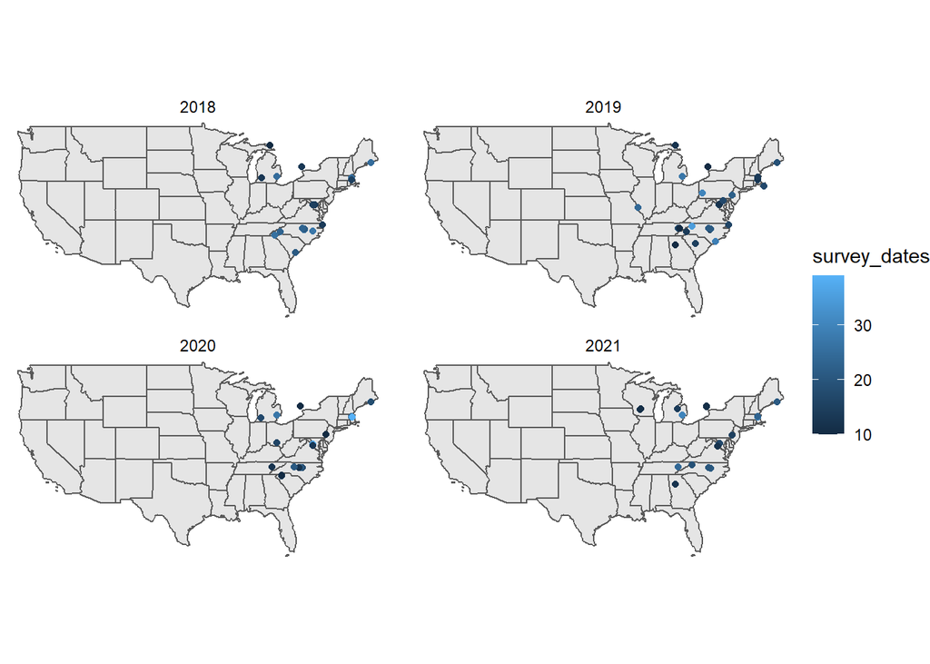

## Assessing percent cover and landscape metrics data

For this initial assessment, I’m only working with the data from the 3000m buffer scale. I’ll do some comparisons across scales later.

Let’s look at the data distributions for all of our statistics across sites with 10 or more sampling dates.

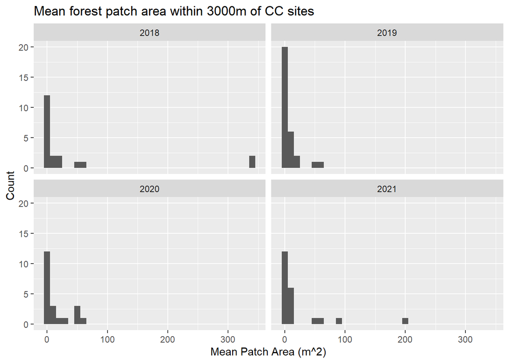

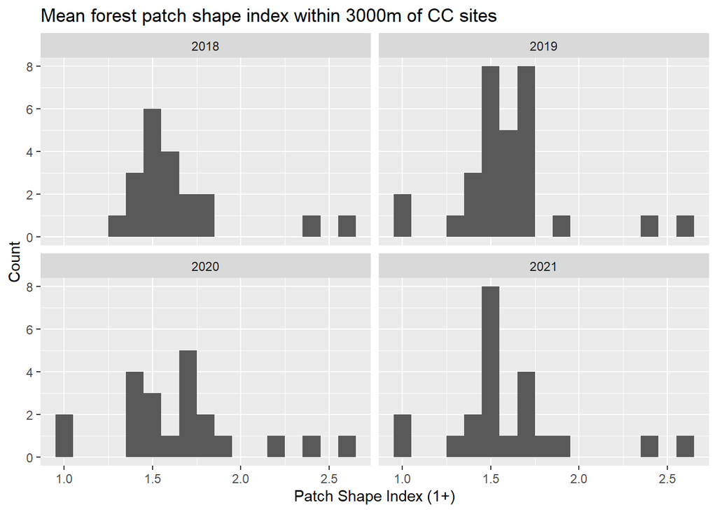

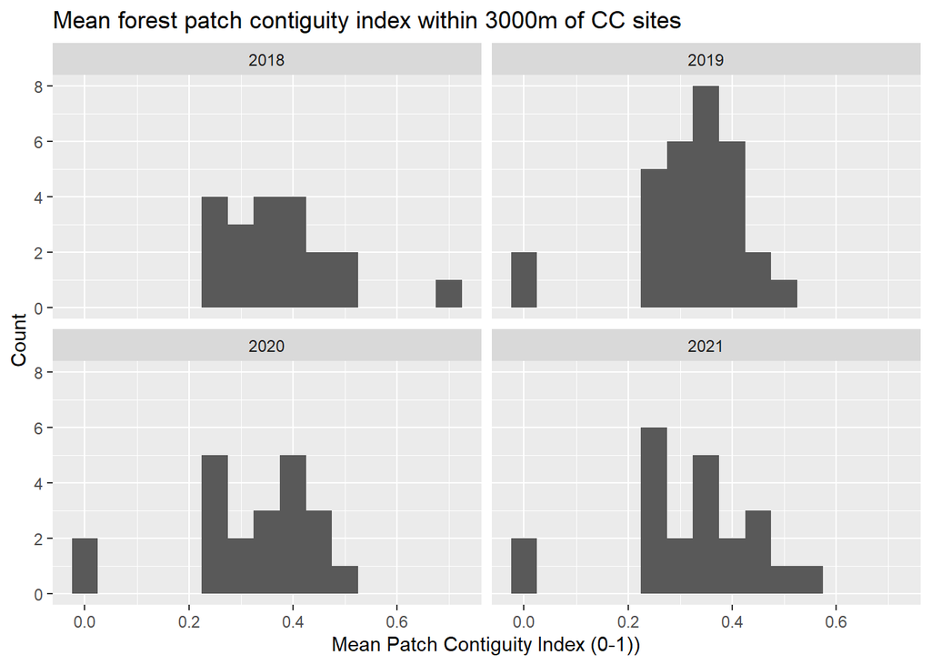

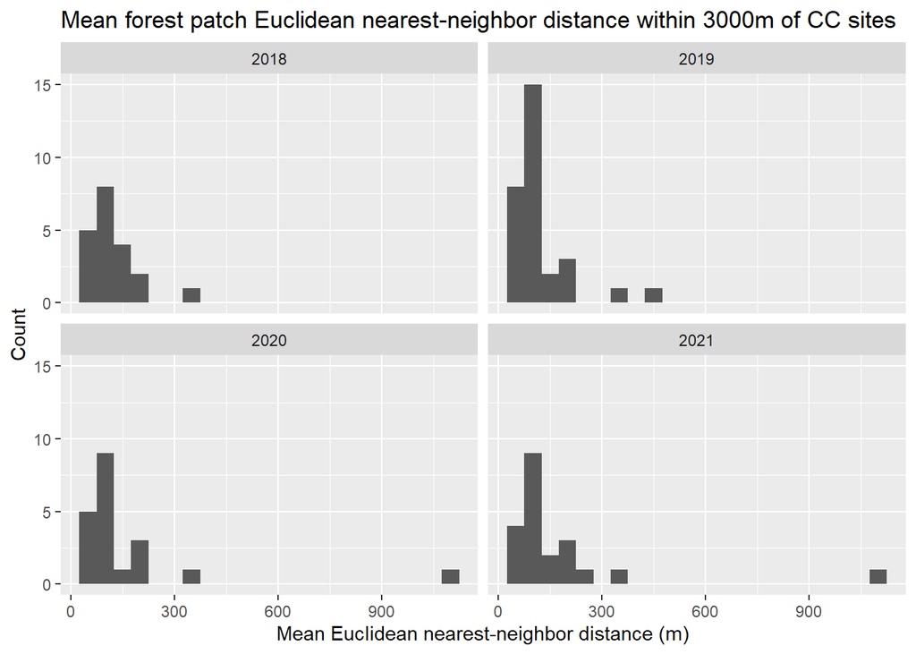

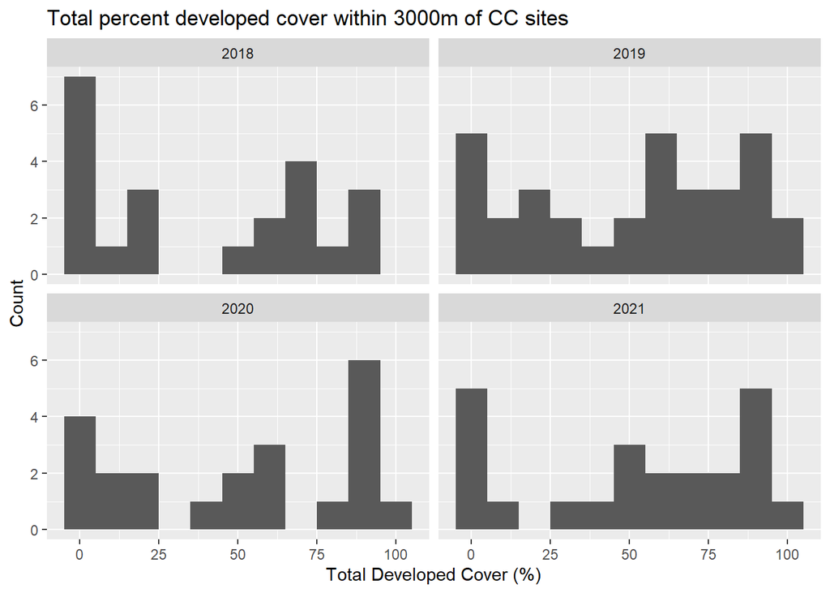

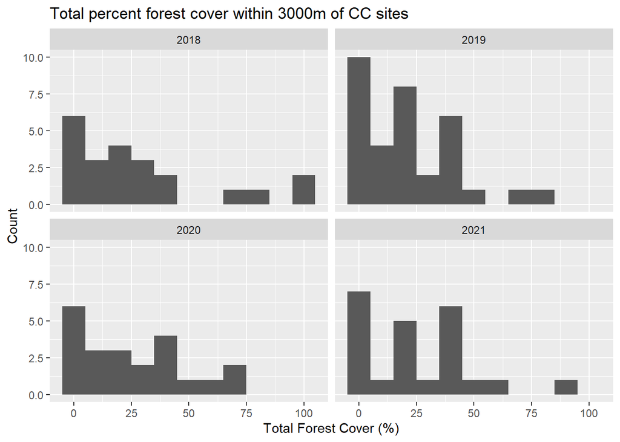

## Mapping CC sites by landscape characteristics

To get a sense of the geographic distribution of sites with different landscape characteristics, I’m mapping the sites by different statistics, still at the 3000m level. Each map includes all the sites present in any of the four sampling years to be used (2018-2021).

Log-transforming mean patch area largely fixes the skew. Nearest-neighbor distance is still super right-skewed, even after being log-transformed, so we’ll need to figure out a different transformation or model to use for that. I have it log-transformed for the map just to make it a little more comprehensible.

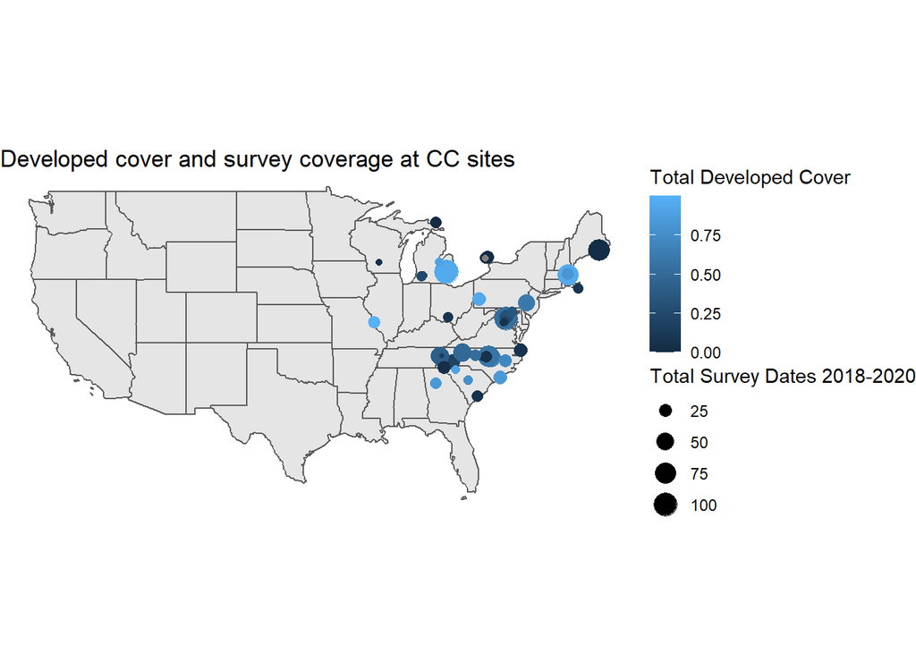

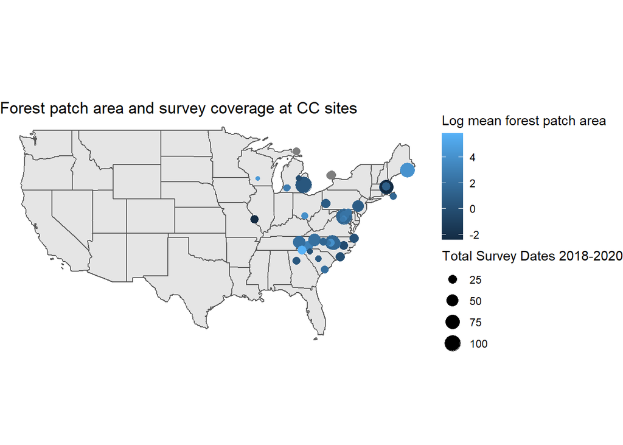

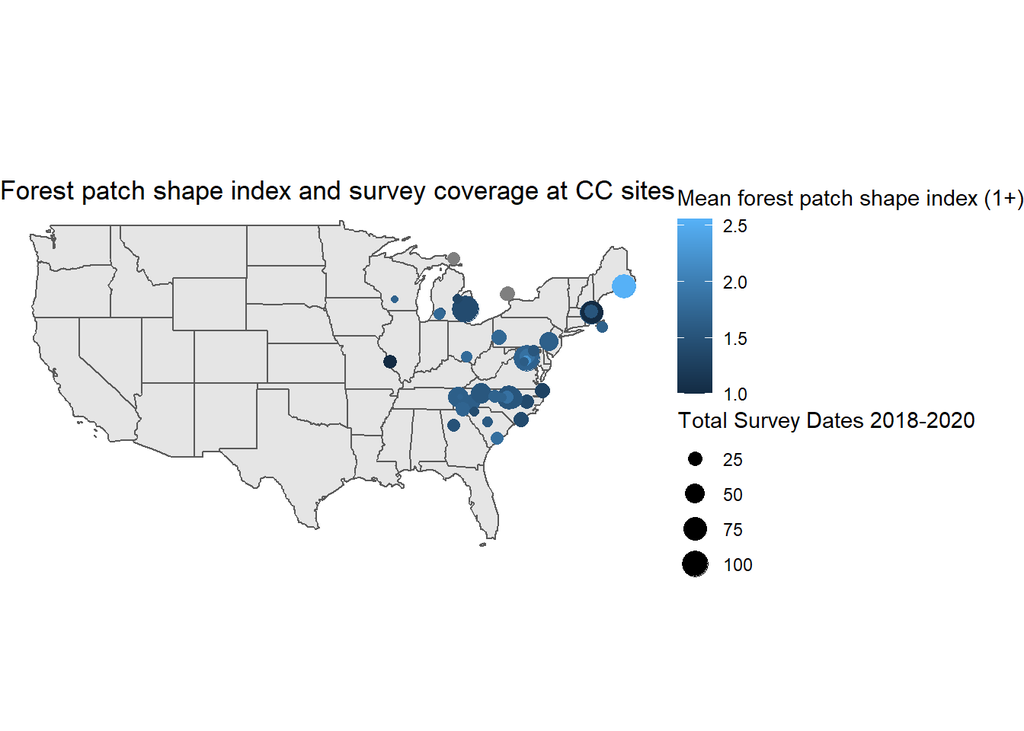

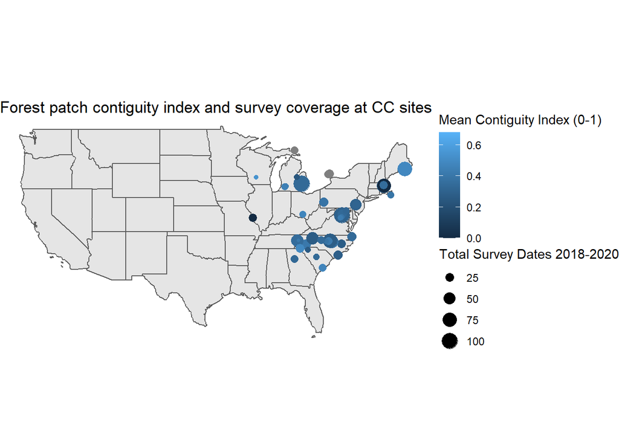

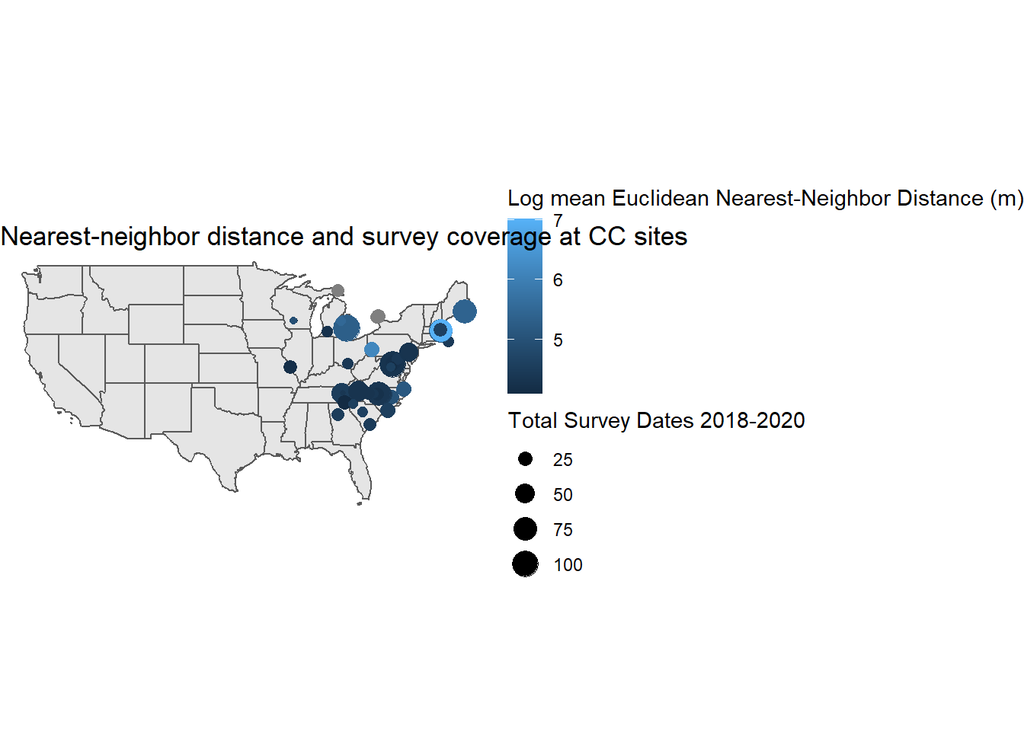

Site location and survey coverage seem to be pretty even across the range of developed cover.

Next steps:

1. Compare and look for correlations in land cover and LSM data across the different scales.
2. Start assessing correlations between landscape statistics and CC data - what CC statistics do we want to start with?